# Project-3

# Introduction

The goal of this project is to use plotly to make some funky plots of real and complex Fibonacci numbers, for the Week 3 Project as part of Course 9 of the Data Science Specialization on Coursera, “Developing Data Products”. Primarily inspired by Stand-up Maths’ YouTube video “Complex Fibonacci Numbers?” (https://www.youtube.com/watch?v=ghxQA3vvhsk).

This project was completed on **August 2, 2020**.

```r
suppressPackageStartupMessages(library(plotly))
library(magrittr)
```

# Real Fibonacci Numbers, Part 1

Start by generalizing the Fibonacci numbers from integers to the whole real number line. The Binet formula for the nth Fibonacci number can take non-integer inputs, but it will produce complex results. This is 3D information, with a 1D input and 2D output. An easy way to represent it is a line graph on the complex plane. This first graph shows only the real Fibonacci numbers from 0 to 5, and maps the path that the Fibonacci sequence travels along the complex plane. Whole values are shown as black dots, always falling at whole numbers along the real line.

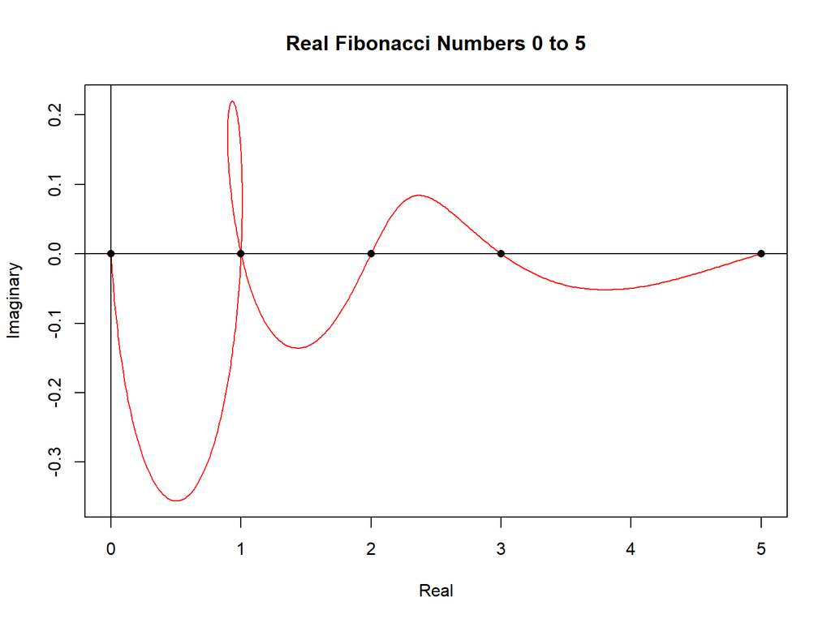

```r
phi <- (1+sqrt(5))/2
binet <- function(x) {((phi^x) - ((-1/phi)^x))/sqrt(5)}
plot(binet(complex(real=seq(0, 5, 0.01))), type='l', col='red', main="Real Fibonacci Numbers 0 to 5", xlab="Real", ylab="Imaginary")
points(binet(complex(real=0:5)), pch=16)
abline(h=0)
abline(v=0)
```

# Real Fibonacci Numbers, Part 2

Next, show from -5 to 5. Positive values of n are shown in red, negative values in blue.

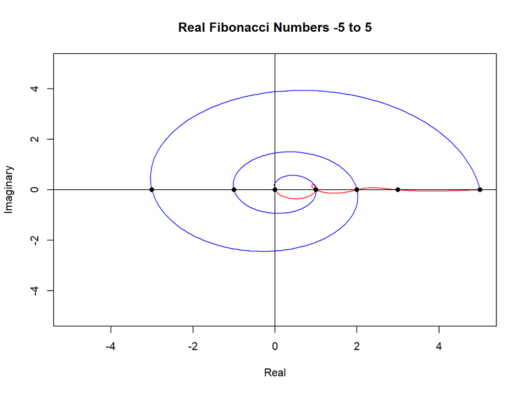

```r
phi <- (1+sqrt(5))/2
binet <- function(x) {((phi^x) - ((-1/phi)^x))/sqrt(5)}
plot(binet(complex(real=seq(0, 5, 0.01))), type='l', col='red', ylim=c(-5,5), xlim=c(-5, 5), main="Real Fibonacci Numbers -5 to 5", xlab="Real", ylab="Imaginary")
lines(binet(complex(real=seq(-5, -0.1, 0.01))), type='l', col='blue')
points(binet(complex(real=-5:5)), pch=16)
abline(h=0)
abline(v=0)
```

# Real Fibonacci Numbers, Part 3

Finally, we can attempt to show this 3D information in 3D, using Plotly. This will have three axes. Input is the input to the Binet formula. Real is the real component of the Fibonacci sequence, and Imaginary is the imaginary component.

```r
phi <- (1+sqrt(5))/2
binet <- function(x) {((phi^x) - ((-1/phi)^x))/sqrt(5)}
n <- seq(-10, 10, 0.01)
fib <- binet(complex(real=n))
plot_ly(x=~n, y=~Re(fib), z=~Im(fib), type='scatter3d', mode='lines', colors = colorRamp(c('blue', 'gray', 'red'))) %>%
  layout(title="3D Visualization of Real Fibonacci Path", scene=list(xaxis=list(title="Input"), yaxis=list(title="Real"), zaxis=list(title="Imaginary")))
```

[interactive chart not shown]

# Complex Fibonacci Numbers, Part 1

Of course, the next step from real-indexed Fibonacci numbers with complex values is complex-indexed Fibonacci numbers with complex values. This is 4D information with a 2D input and 2D output, however, making it a bit hard to visualize. One way to alleviate this is to split it the results into two graphs, representing the real and imaginary outputs separately. Stick with positive input values, since things get really messy really quickly in the othe quadrants.

```r
phi <- (1+sqrt(5))/2
binet <- function(x) {((phi^x) - ((-1/phi)^x))/sqrt(5)}
a <- 10
real <- matrix(1:a^2, nrow = a)
imag <- matrix(1:a^2, nrow = a)
for (x in 1:a) {
  for (i in 1:a) {
    c <- binet(complex(real=x,imaginary=i))
    real[x,i] <- Re(c)
    imag[x,i] <- Im(c)
  }
}
plot_ly(z=~real, type="surface", colors = colorRamp(c('blue', 'gray', 'red'))) %>%
  layout(title="Real Component of Output", scene=list(xaxis=list(title="Real Input"), yaxis=list(title="Imaginary Input"), zaxis=list(title="Real Output")))
```

[interactive chart not shown]

```r
plot_ly(z=~imag, type="surface", colors = colorRamp(c('blue', 'gray', 'red'))) %>%
  layout(title="Imaginary Component of Output", scene=list(xaxis=list(title="Real Input"), yaxis=list(title="Imaginary Input"), zaxis=list(title="Imaginary Output")))
```

[interactive chart not shown]

# Complex Fibonacci Numbers, Part 2

Next, attempt to unify these two plots into a single surface, by color-coding the imaginary component.

```r
phi <- (1+sqrt(5))/2
binet <- function(x) {((phi^x) - ((-1/phi)^x))/sqrt(5)}
a <- 10
real <- matrix(1:a^2, nrow = a)
imag <- matrix(1:a^2, nrow = a)
for (x in 1:a) {
  for (i in 1:a) {
    c <- binet(complex(real=x,imaginary=i))
    real[x,i] <- Re(c)
    imag[x,i] <- Im(c)
  }
}
plot_ly(z=~real, type="surface", scene='r', colors = colorRamp(c('blue', 'gray', 'red')), surfacecolor=imag) %>%
  layout(title="The Full Fledged Four-D Fibonacci!", scene=list(xaxis=list(title="Real Input"), yaxis=list(title="Imaginary Input"), zaxis=list(title="Real Output"))) %>%
  colorbar(title="Imaginary Output")
```

[interactive chart not shown]